# Создание проектов

[figure not shown]

Александр Шишков (Itseez, ННГУ)  
Март 2016

# Содержание

1. IDE
2. Билд-системы
3. CMake

# IDE

> **Интегрированная среда разработки, ИСР** (англ. **IDE, Integrated development environment** или **integrated debugging environment**) — система программных средств, используемая программистами для разработки программного обеспечения.

В чем отличие IDE от редакторов исходного кода?

# Основные модули IDE

IDE - это не только ценный мех:

- Текстовый редактор
- Компилятор и/или интерпретатор
- Средства автоматизации сборки
- Отладчик

# Функции современных IDE

- Автодополнение кода
- Поддержка шаблонов проектов
- Сниппеты
- Поддержка систем контроля версий
- Интеграция задач (`//TODO: ...`)
- Браузер классов
- Визульное редактирование классов
- Инструменты рефакторинга
- Профилировщик
- Работа с СУБД, веб-сервисами
- и т.д.

# Плагины для IDE

JetBrains [Resharper](http://www.jetbrains.com/resharper/features/index.html)

- Статический анализ кода
- Сниппеты
- Инструменты рефакторинга
- Поддержка unit-тестов
- Инструменты автогенерации кода
- ...

# Классификация IDE

1. По количеству поддерживаемых языков
   - NetBeans, Xcode, Microsoft Visual Studio
   - Visual Basic, Delphi, Dev-C++
2. Online/offline
   - NetBeans, Xcode, Microsoft Visual Studio
   - Eclipse Орион, Cloud 9 IDE, eXo Cloud IDE, ideone

# Сравнение С++ IDE

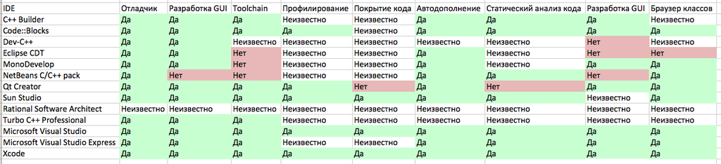

# Содержание

1. IDE
2. Билд-системы
3. CMake

# Цель

После написания кода приложения необходимо уметь:

- компилировать файлы с исходным кодом
- линковать их с библиотеками
- распространять их как (source/binary)
- запускать тесты

# Компиляция

Как компилировать?

- gcc c a.out main.cpp

# Компиляция

А теперь представим:

- проект содержит несколько тысяч файлов
- некоторые файлы должны компилироваться только на некоторых ОС
- для разных заказчиков вы должны собирать проект:
  - с разными define (DEBUG/RELEASE, LOG)
  - для разных ОС
  - для разных компиляторов
  - ...

# Линковка и другие аспекты

- Линковка
- Распространение приложений
  - .rpm, .msi, .dmg, .exe, InstallShield, .tar.gz, .zip, .7z, ...
- Тестирование

# История

- shell скрипты

compile.sh:

```
#!/bin/sh
cc -c main.c
cc -c lib.c
cc -o program main.o lib.o
```

- make, 1977 год

Makefile:

```
OBJ = main.o lib.o
program: $(OBJ)
        cc -o program $(OBJ)
$(OBJ): defines.h
```

# Autotools

Makefile.am:

```
bin_PROGRAMS = hello
hello_SOURCES = main.c lib.c
```

configure.ac:

```
AC_INIT([program], [1.0], [sample@mail.org])
AM_INIT_AUTOMAKE([-Wall -Werror foreign])
AC_PROG_CC
AC_CONFIG_HEADERS([config.h])
AC_CONFIG_FILES([
 Makefile
])
AC_OUTPUT
```

Для запуска:

```
autoreconf --install
./configure
make
```

# Autotools

Было де-факто стандартом и до сих пор используется, но:

- слишком сложно
- только Unix
- sh, m4
- зависимости

# Содержание

1. IDE
2. Билд-системы
3. CMake

[figure not shown]

# CMake

[figure not shown]

- Широкая поддержка разнообразных целевых платформ и IDE
- Максимальная свобода в выборе окружения разработки (в рамках одной команды!)
- В настоящий момент является стандартом де-факто для С++ проектов

# CMake Workflow

`CMakeLists.txt` — файл, описывающий порядок сборки приложения

- **Шаг 0**. Генерация *проектных файлов* при помощи `cmake` или `CMakeGui`
  - `.vcproj, Makefile, etc`
- **Шаг 1**. Компиляция исходников при помощи компиляторов из Visual Studio, Qt Creator, Eclipse, XCode...
  - `.obj, .o`
- **Шаг 2**. Линковка финальных бинарных файлов компоновщиком (link.exe, ld, ...)
  - `.exe, .dll, .lib, .a, .so, .dylib`

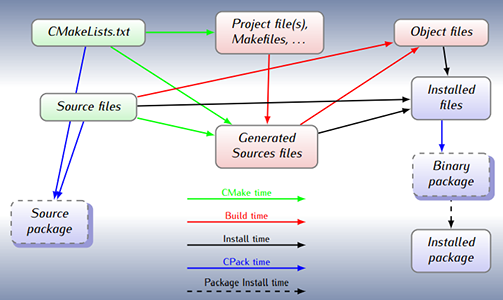

# CMake GUI

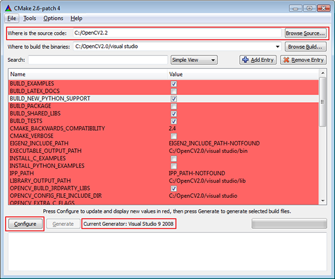

# Out of source build

**Плохо**: в директории с исходным кодом

```
code
├── hello.cpp
└── hello.exe # Этот файл может случайно попасть в историю Git
```

**Хорошо**: вне директории (чистый репозиторий, несколько build-директорий)

```
code
└── hello.cpp
build
└── hello.exe
```

Соответствующие команды:

```bash
$ cd <code>
$ mkdir ../build && cd ../build
$ cmake ../<code>
```

# Пример сборки приложения (`add_executable`)

Содержимое каталога:

```
code
├── CMakeLists.txt
├── lib.h
├── lib.c
└── main.c
```

`CMakeLists.txt`

```
cmake_minimum_required(VERSION 2.8)
project(first_sample)

set(SOURCES main.c lib.c)
add_executable(sample_app ${SOURCES}) # Объявляет исполняемый модуль с именем sample_app
```

# Пример сборки библиотеки (`add_library`)

Содержимое каталога:

```
code
├── CMakeLists.txt
├── lib.h
├── lib.c
└── main.c
```

`CMakeLists.txt`

[output not shown]

# Debug / Release

В `CMakeLists.txt`:

```
SET(CMAKE_BUILD_TYPE Debug)
```

В командной строке:

```bash
$ cmake -DCMAKE_BUILD_TYPE=Debug ../code # Запомните эту команду!
```

Для библиотек:

```
TARGET_LINK_LIBRARIES(lib RELEASE ${lib_SRCS})
TARGET_LINK_LIBRARIES(libd DEBUG ${lib_SRCS})
```

# Добавление подпроекта

Содержимое каталога:

```
code
├── CMakeLists.txt
├── library
│   ├── CMakeLists.txt
│   ├── lib.c
│   └── lib.h
└── main.c
```

Корневой `CMakeLists.txt`:

```
cmake_minimum_required(VERSION 2.8)
project(third_sample)

add_subdirectory(library) # Указывает, что в директории library есть свой CMakeLists.txt

include_directories(library)
set(SOURCES main.c)
add_executable(sample_app ${SOURCES})

target_link_libraries(sample_app library)
```

# Добавление подпроекта (#2)

`library/CMakeLists.txt`

```
cmake_minimum_required(VERSION 2.8)
project(library)

set(SOURCE_LIB lib.c)
add_library(library STATIC ${SOURCE_LIB})
```

# Поиск библиотек

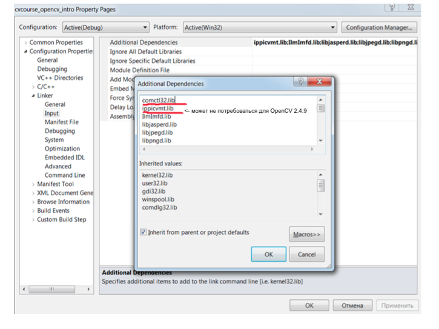

# Поиск зависимостей

`CMakeLists.txt`

```
cmake_minimum_required(VERSION 2.8)
project(sample)

# Поиск OpenCV
find_package(OPENCV REQUIRED)
if(NOT OPENCV_FOUND)
    message(SEND_ERROR "Failed to find OpenCV")
    return()
else()
    include_directories(${OPENCV_INCLUDE_DIR})
endif()

add_executable(sample_app main.c)
target_link_libraries(sample_app ${OPENCV_LIBRARIES})
```

# CMake: Резюме

- Основной "недостаток" — собственный язык
- Поначалу инструмент кажется нетривиальным, но очень удобен впоследствии
- Дает членам команды максимальную свободу в выборе инструментов  
  (OC, IDE или простой текстовый редактор)
- Обеспечивает переносимость и является стандартом де-факто  
  для кросс-платформенных С++ проектов

# Билд-системы

Популярные билд-системы:

- [SCons](http://www.scons.org)
  - [Waf](https://code.google.com/p/waf/)
- [Rake](https://github.com/ruby/rake)
- [Makeit](https://bitbucket.org/grahamdumpleton/makeit)
- [Jam](http://www.perforce.com/resources/documentation/jam)
- [qmake](http://en.wikipedia.org/wiki/Qmake)
- [Maven](http://maven.apache.org/)

# Резюме

1. Использование современных IDE может существенно облегчить процесс разработки.
2. Метапрограммирование позволяет динамически создавать однотипный код.
3. Билд-системы - незаменимый инструмент при разработке кроссплатформенных приложений.

# Контрольные вопросы

1. Определение ИСР
2. Отличия ИСР от редакторов исходного кода
3. Основные функции/возможности современных ИСР
4. Иcтория развития билд-систем
5. Плюсы и минусы Makefile
6. Плюсы и минусы CMake

# Ссылки

1. http://ru.wikipedia.org/wiki/Сравнение_IDE
2. http://rus-linux.net/lib.php?name=/MyLDP/algol/lex-yacc-howto.html
3. http://www.scons.org/wiki/SconsVsOtherBuildTools

# Спасибо!

Вопросы?